# GRH Forecast Evaluation

### Percent Bias

#### Overall

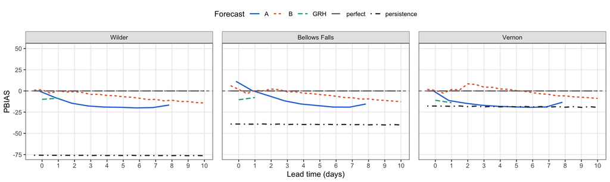

#### Winter

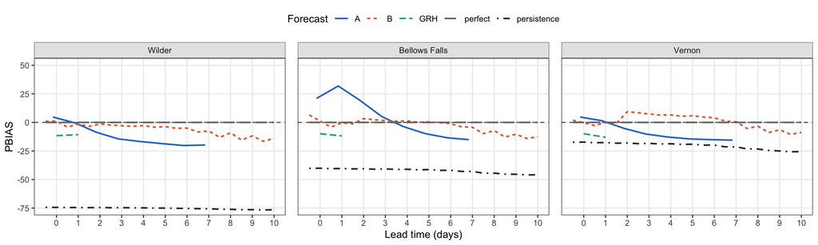

#### Spring

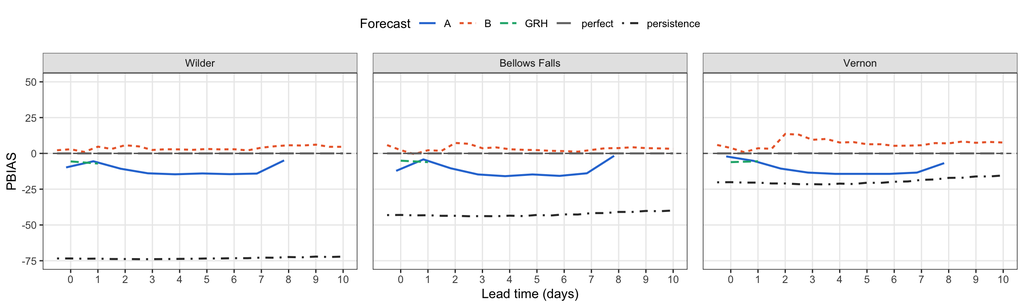

#### Summer

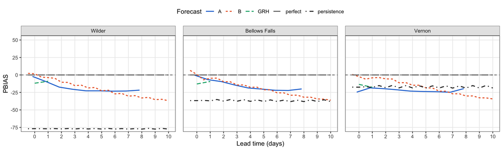

#### Fall

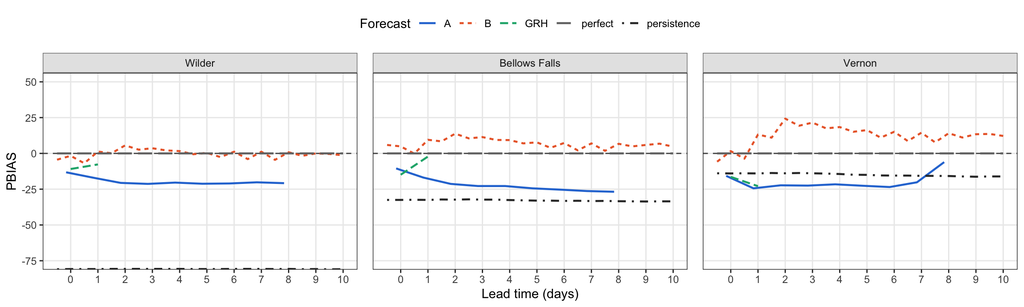

## Hourly forecast performance vs lead time

### Kling-Gupta Efficiency (KGE)

#### Overall

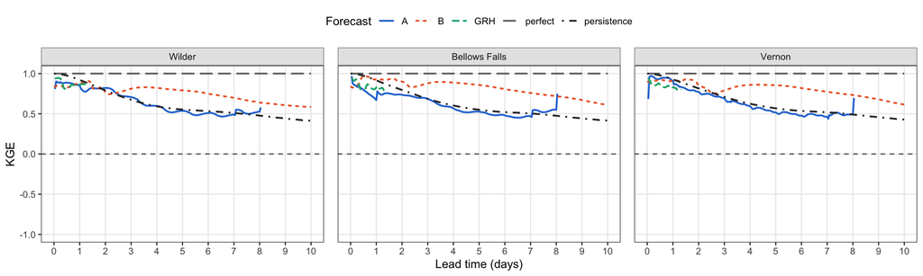

#### Winter

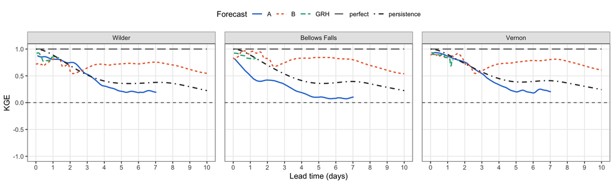

#### Spring

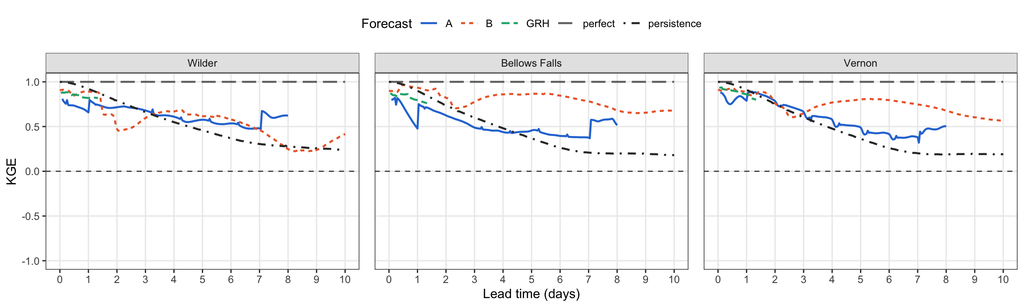

#### Summer

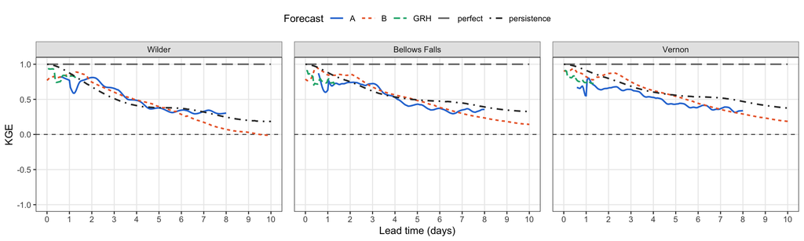

#### Fall

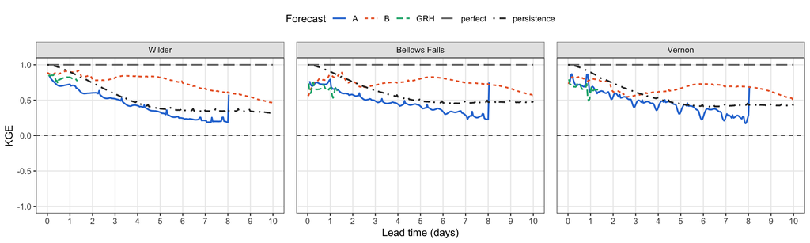

### Nash-Suttecliffe Efficiency (NSE) {.tabset}

#### Overall

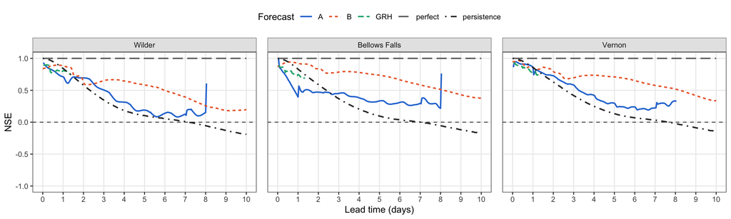

#### Winter

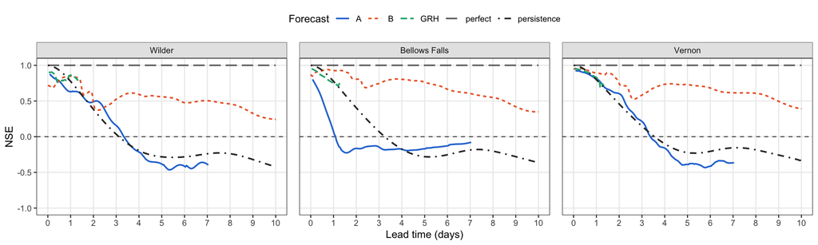

#### Spring

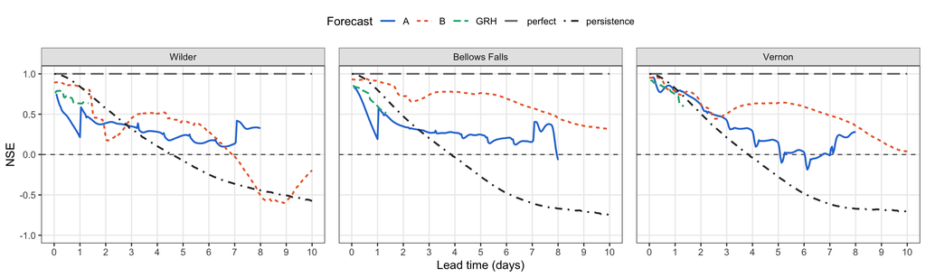

#### Summer

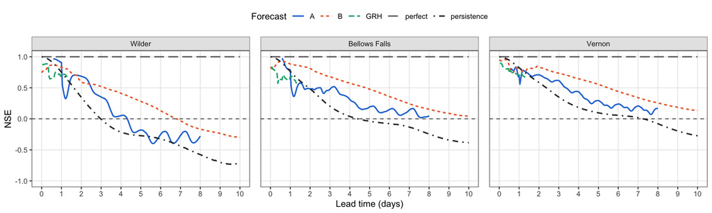

#### Fall

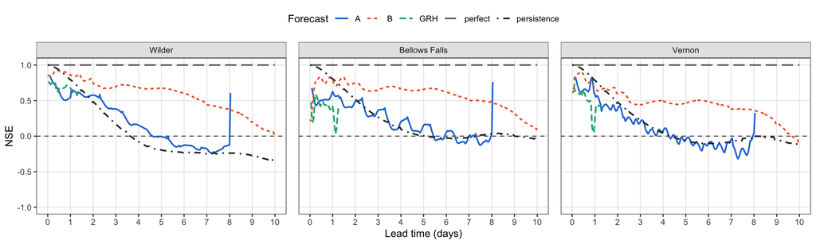

### Pearson’s Correlation (r)

#### Overall

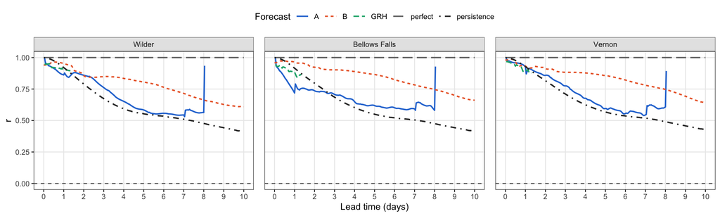

#### Winter

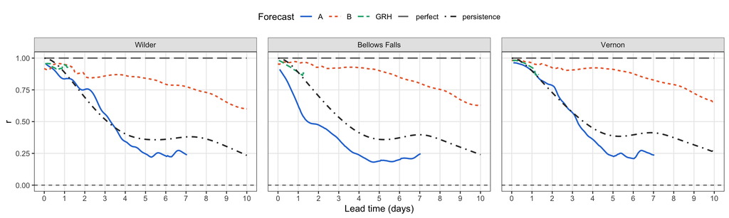

#### Spring

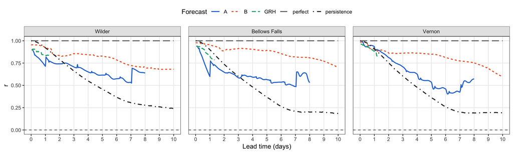

#### Summer

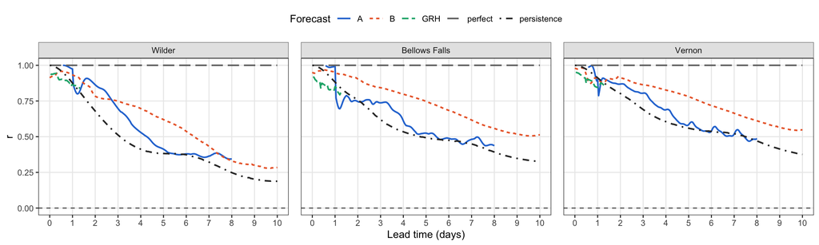

#### Fall

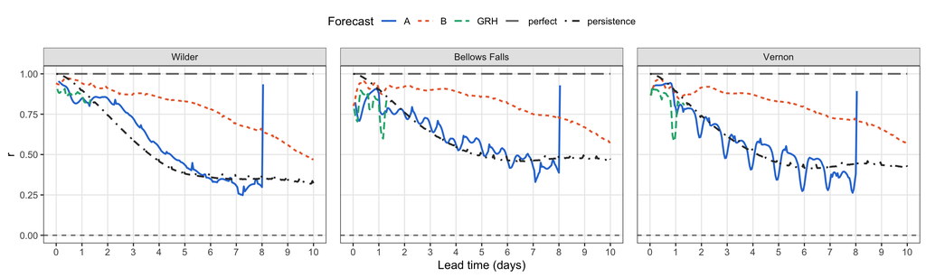

### Percent Bias

#### Overall

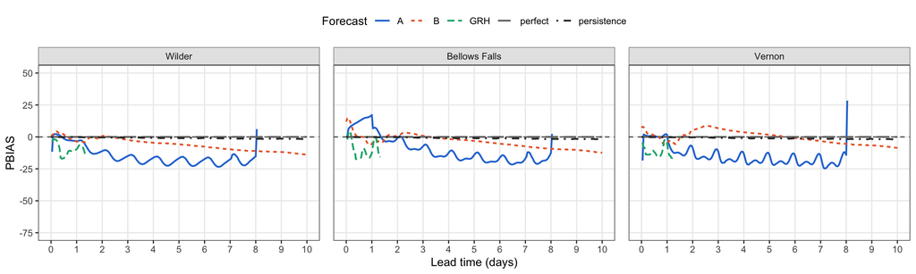

#### Winter

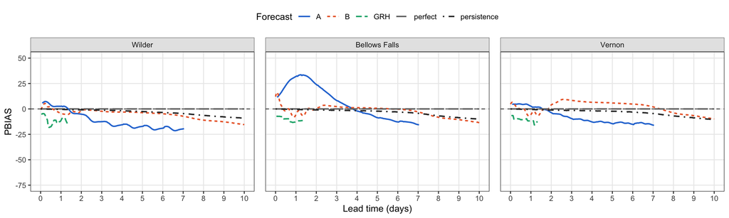

#### Spring

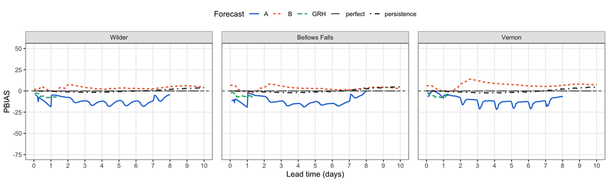

#### Summer

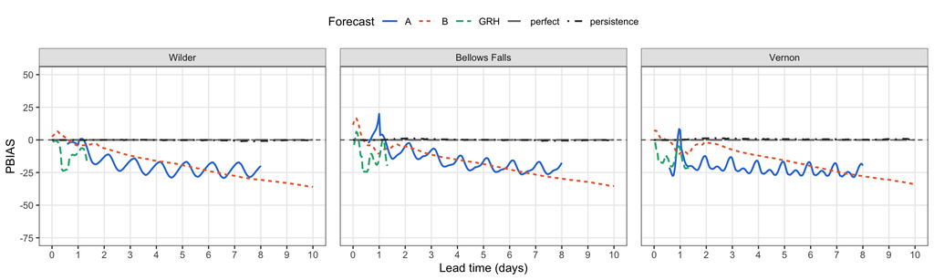

#### Fall

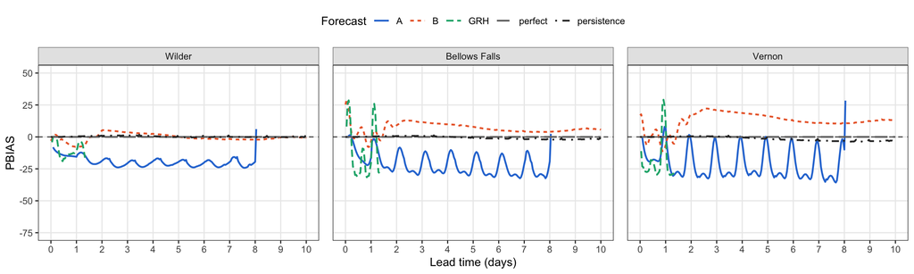

## Cumulative Error

Cumulative inflow error is what moves the forebay, so it is accumulated over each issue’s own delivered horizon rather than over absolute lead time. Forecast A is issued at 04:00 but for most of its issues the delivered series does not start until lead hour 25, so an absolute-lead axis compares 8 accumulated hours of A against 32 of B and produces a non-monotonic A curve driven purely by sample composition. Indexing by position in the horizon keeps every row and makes each point a like-for-like N-hour accumulation. This is the same construction as paper Figures 5 and 6 (`make-revision-figures.R`).

Only the three forecast products appear here. `perfect` accumulates exactly zero by construction and `persistence` is a day-ahead benchmark, so neither is informative on an hourly accumulation.

### 2.5th to 97.5th percentile (Middle 95%)

Paper Figure 5 is the “Overall” tab.

#### Overall

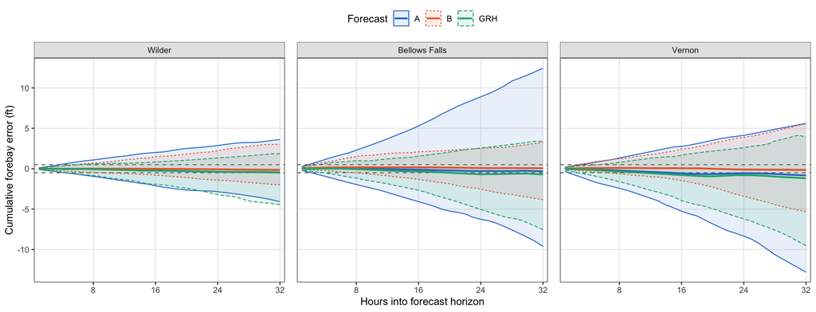

#### Winter

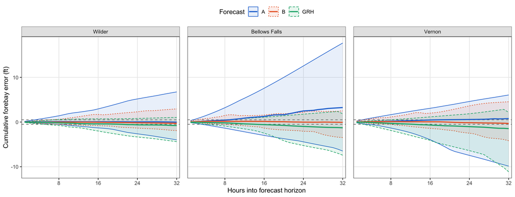

#### Spring

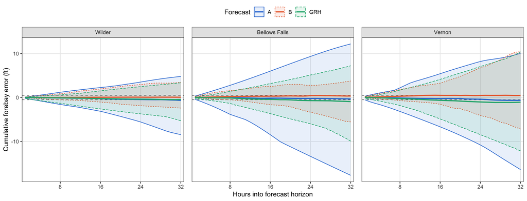

#### Summer

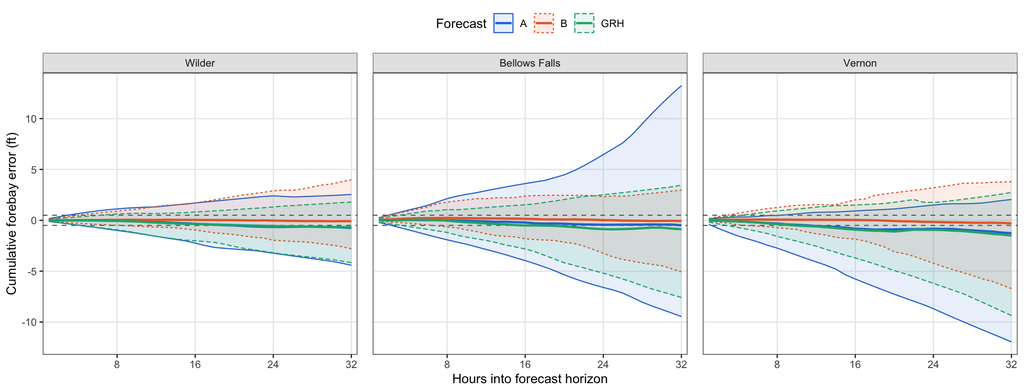

#### Fall

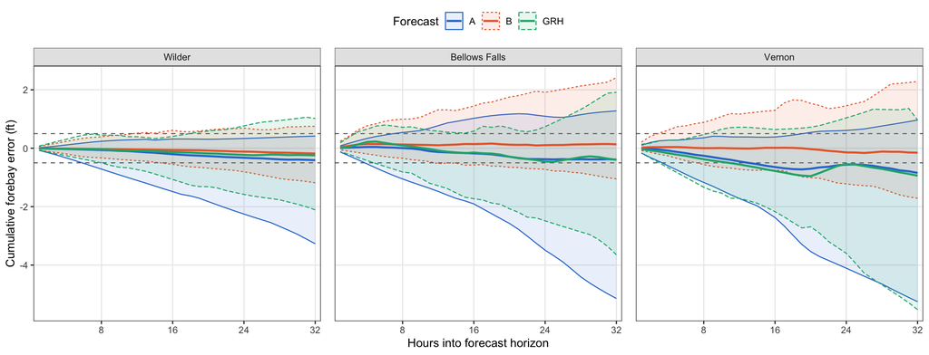

### 25th to 75th percentile (Middle 50%)

The same plot over the interquartile range instead of the middle 95%.

#### Overall

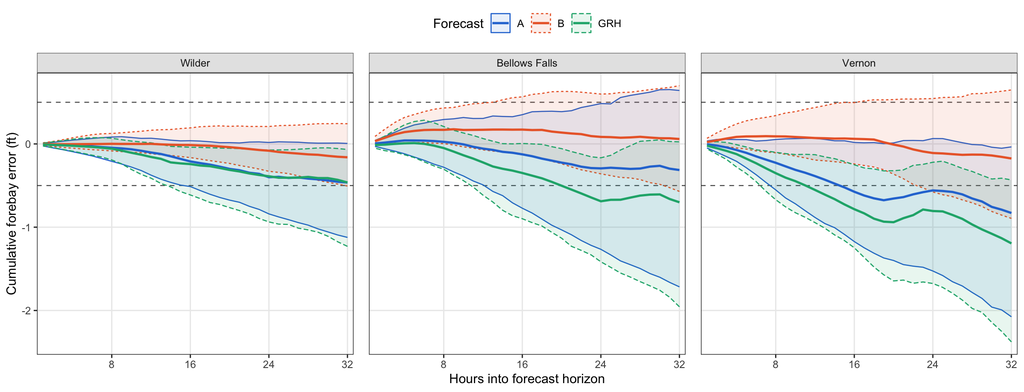

#### Winter

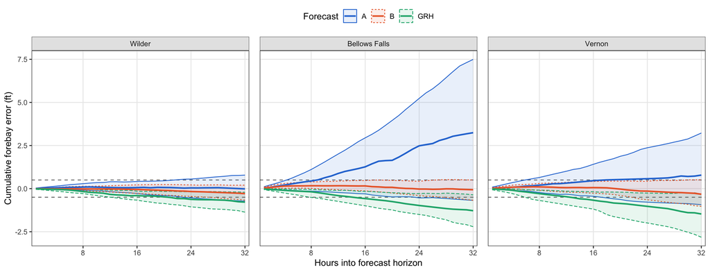

#### Spring

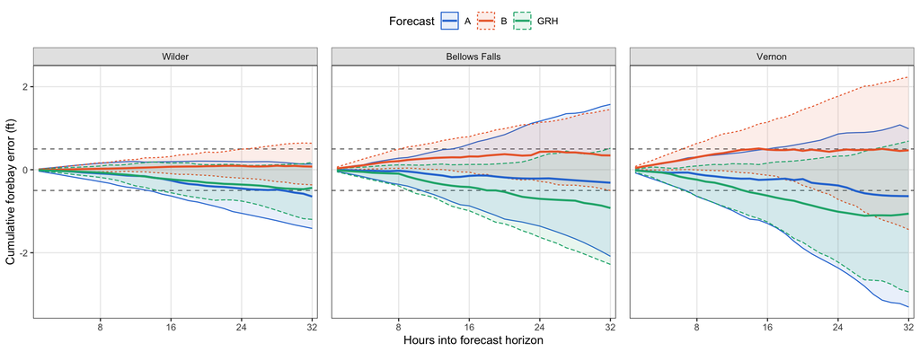

#### Summer

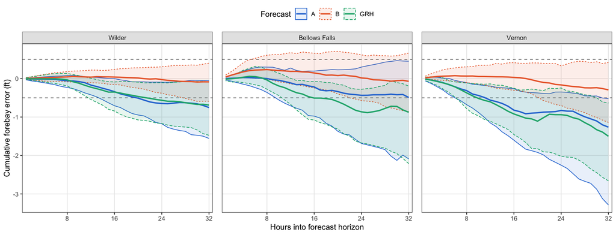

#### Fall

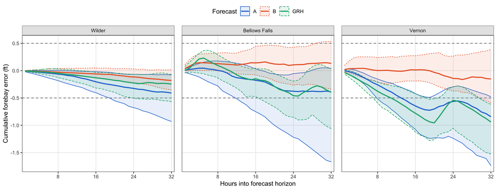

## Probability of exceeding 0.5 ft cumulative error

Paper Figure 6 is the “Overall” tab, restricted to the marked hours.

### Overall

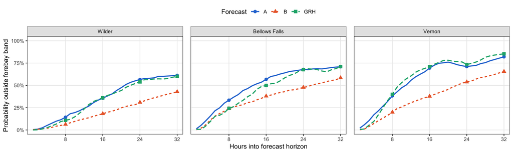

### Winter

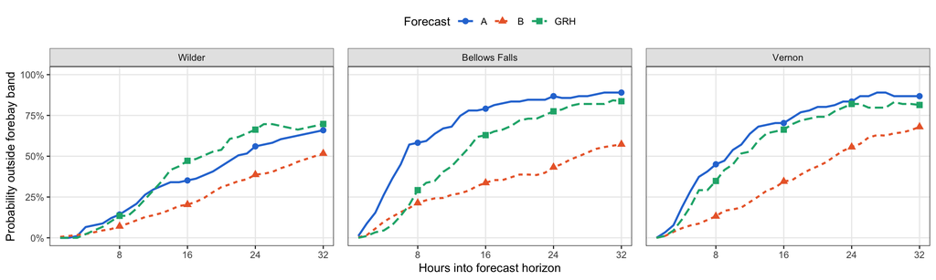

### Spring

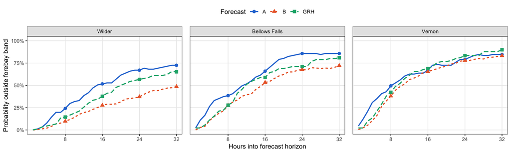

### Summer

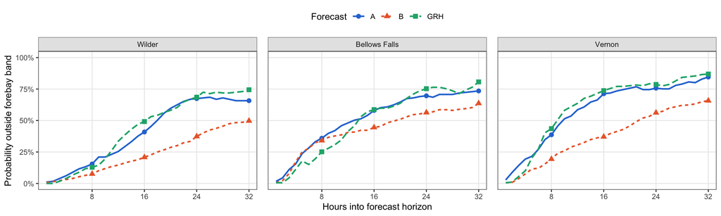

### Fall

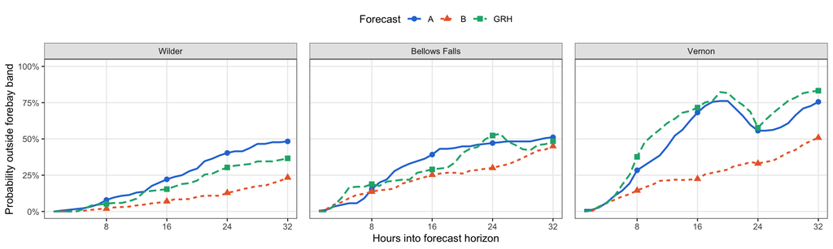